# Module 7 Project Report

Ana Pirosca, Jonah Kotzen, Katie Miller, Jessica Stolz

2023-11-19

# Introduction

How do muscles work when you’re tired? Recognizing the fundamental role of length in muscle force generation, we will explore the impact of fatigue on the force-length relationship, particularly focusing on the upper limb’s forearm flexors and their 3rd order lever system. While previous research has delved into the basics of muscle mechanics, the missing piece that makes our study relevant is a comprehensive exploration of how fatigue specifically influences the force-length relationship in the context of isometric muscle contractions, offering insights into practical scenarios like sustained muscle effort or prolonged physical activity (Enoka and Duchateau (2008)).

Thus, we have two big questions: First, do the data about how much force your muscles can make match a certain pattern when you’re pushing against something? Second, does the angle at which your muscles work change when you’re tired compared to when you’re not tired? Our investigation dives into the biomechanical aspects of muscle architecture, considering the mediation of force at the fiber level by crossbridges and the implications of lever configurations. (Chen, Nosaka, and Sacco (2007))

# Methods

In order to answer the questions above, we obtained experimental data by fabricating and programming a load-cell data acquisition system (via Arduino) then we recorded isometric MVCs at 12 distinct elbow angle by moving the upper body in different locations relative to the goniometer that is secured to a table. In orer to obtain fatigued data, we eccentrically lowered heavy items with the same arm used in the initial experiment, waited two minutes, then performed the isometric MVCs again.

## Software and Coding the Arduino

The Arduino was programmed using the following sketch…

HX711 scale;

void setup() { Serial.begin(115200); scale.begin(6, 7); scale.tare(); }

void loop() { float newReading = scale.get_units(10); Serial.println(newReading); }

## Manipulation of the New Data into Meta Data Sorting

### Meta Data

```r
# Get all CSV files in the 'new_data' folder
file_paths <- list.files(path = "new_data", pattern = "\\.csv$", full.names = TRUE)

# Initialize an empty tibble to store the combined metadata
combined_metadata <- tibble(
  TeamName = character(),
  Person = character(),
  State = character(),
  Angle = double()
)

# Process each file
for (file_path in file_paths) {
  # Extract only the file name from the file path
  file_name <- basename(file_path)

# Extract metadata from the file name
parts <- str_match(file_name, "([a-zA-Z0-9]+)_(.+)_(control|fatigue)_(\\d+(\\.\\d+)?)\\.csv")

if (nrow(parts) > 0) {
  teamname <- parts[, 2]
  person <- parts[, 3]
  state <- parts[, 4]
  angle <- as.numeric(parts[, 5])  # Convert angle to numeric

    # Create a tibble with the extracted metadata
    metadata <- tibble(
      TeamName = teamname,
      Person = person,
      State = state,
      Angle = angle,
      FileName = file_name
    )

    # Combine with the combined_metadata tibble
    combined_metadata <- bind_rows(combined_metadata, metadata)
  }
}

# Print the combined metadata tibble
print(combined_metadata)
```

```
## # A tibble: 564 × 5
##    TeamName   Person    State   Angle FileName
##    <chr>      <chr>     <chr>   <dbl> <chr>
##  1 armstrongg elisabeth control 101.  armstrongg_elisabeth_control_101.25.csv
##  2 armstrongg elisabeth control 112.  armstrongg_elisabeth_control_112.5.csv
##  3 armstrongg elisabeth control 124.  armstrongg_elisabeth_control_123.75.csv
##  4 armstrongg elisabeth control 135   armstrongg_elisabeth_control_135.csv
##  5 armstrongg elisabeth control 146.  armstrongg_elisabeth_control_146.25.csv
##  6 armstrongg elisabeth control 158.  armstrongg_elisabeth_control_157.5.csv
##  7 armstrongg elisabeth control 169.  armstrongg_elisabeth_control_168.75.csv
##  8 armstrongg elisabeth control  45   armstrongg_elisabeth_control_45.csv
##  9 armstrongg elisabeth control  56.2 armstrongg_elisabeth_control_56.25.csv
## 10 armstrongg elisabeth control  67.5 armstrongg_elisabeth_control_67.5.csv
## # ℹ 554 more rows
```

### Factoring in Force

```r
force_data <- read.csv(file_path) %>% select(force)
```

```r
# Define the function to read and process each file
read_and_process_file <- function(file_path) {
  force_data <- read.csv(file_path) %>% select(force)
  tibble(filename = basename(file_path), force = force_data$force)
}

# Create an empty list to store the results
combined_data <- list()

# Loop through file_paths and read/append data
for (file_path in file_paths) {
  data <- read_and_process_file(file_path)
  combined_data <- append(combined_data, list(data))
}

# Combine the list of data frames into a single tibble
combined_data <- bind_rows(combined_data)

print(combined_data)
```

```
## # A tibble: 10,642 × 2
##    filename                                 force
##    <chr>                                    <dbl>
##  1 armstrongg_elisabeth_control_101.25.csv 20204.
##  2 armstrongg_elisabeth_control_101.25.csv 21114.
##  3 armstrongg_elisabeth_control_101.25.csv 20189.
##  4 armstrongg_elisabeth_control_101.25.csv 19917.
##  5 armstrongg_elisabeth_control_101.25.csv 20986.
##  6 armstrongg_elisabeth_control_101.25.csv 20583.
##  7 armstrongg_elisabeth_control_101.25.csv 20396.
##  8 armstrongg_elisabeth_control_101.25.csv 19682.
##  9 armstrongg_elisabeth_control_101.25.csv 20931.
## 10 armstrongg_elisabeth_control_101.25.csv 20535.
## # ℹ 10,632 more rows
```

```r
# Get all CSV files in the 'new_data' folder
file_paths <- list.files(path = "new_data", pattern = "\\.csv$", full.names = TRUE)

# Initialize an empty list to store the combined data
combined_data_list <- list()

# Process each file
for (file_path in file_paths) {
  # Extract only the file name from the file path
  file_name <- basename(file_path)

  # Extract metadata from the file name
  parts <- str_match(file_name, "([a-zA-Z0-9]+)_(.+)_(control|fatigue)_(\\d+(\\.\\d+)?)\\.csv")

  if (nrow(parts) > 0) {
    teamname <- parts[, 2]
    person <- parts[, 3]
    state <- parts[, 4]
    angle <- as.numeric(parts[, 5])  # Convert angle to numeric

    # Read force_data and select the 'force' column
    force_data <- read.csv(file_path) %>% select(force)

    # Create a tibble with the extracted metadata
    metadata <- tibble(
      TeamName = teamname,
      Person = person,
      State = state,
      Angle = angle,
      Force = force_data$force  # Add the 'force' column
    )

    # Store the combined data in the list
    combined_data_list[[file_name]] <- metadata
  }
}


# Combine the list of data frames into a single data frame
combined_data <- do.call(rbind, combined_data_list)

# Calculate Max_Force for each Person and State combination
combined_data <- combined_data %>%
  group_by(Person, State) %>%
  mutate(Max_Force = max(Force, na.rm = TRUE)) %>%
  ungroup()

# Print the combined data tibble
print(combined_data)
```

```
## # A tibble: 10,642 × 6
##    TeamName   Person    State   Angle  Force Max_Force
##    <chr>      <chr>     <chr>   <dbl>  <dbl>     <dbl>
##  1 armstrongg elisabeth control  101. 20204.   303244.
##  2 armstrongg elisabeth control  101. 21114.   303244.
##  3 armstrongg elisabeth control  101. 20189.   303244.
##  4 armstrongg elisabeth control  101. 19917.   303244.
##  5 armstrongg elisabeth control  101. 20986.   303244.
##  6 armstrongg elisabeth control  101. 20583.   303244.
##  7 armstrongg elisabeth control  101. 20396.   303244.
##  8 armstrongg elisabeth control  101. 19682.   303244.
##  9 armstrongg elisabeth control  101. 20931.   303244.
## 10 armstrongg elisabeth control  101. 20535.   303244.
## # ℹ 10,632 more rows
```

# Main Data Methods

## Chunk 1: Load Library and Norm Force

```r
# Load the necessary libraries
library(dplyr)
library(MuMIn)
library(ggplot2)
library(purrr)
library(broom)
library(tidyr)

# 1. Normalize the forces for each experiment
# Ensure the correction is applied to the original data before any other processing
combined_data$Person <- ifelse(tolower(combined_data$Person) %in% c("leticianna", "letiacianna", "letacianna"), "Letacianna", combined_data$Person)

# Now, check to ensure the correction has been applied
print(unique(combined_data$Person))
```

```
##  [1] "elisabeth"  "Lauren"     "Letacianna" "sean"       "yunshu"
##  [6] "alex"       "andrew"     "georgia"    "nicole"     "elizabeth"
## [11] "hannah"     "vanessa"    "Baylie"     "ben"        "michael"
## [16] "Tara"       "Audrey"     "conor"      "Jaan"       "Julia"
## [21] "Leo"        "Susanne"    "ana"        "jess"       "jonah"
## [26] "katie"
```

```r
# After confirming the correction, proceed to normalize the forces
combined_data_norm <- combined_data %>%
  group_by(Person, State) %>%
  mutate(normF = Max_Force / max(Max_Force, na.rm = TRUE)) %>%
  ungroup()

# Print the normalized data
print(combined_data_norm)
```

```
## # A tibble: 10,642 × 7
##    TeamName   Person    State   Angle  Force Max_Force normF
##    <chr>      <chr>     <chr>   <dbl>  <dbl>     <dbl> <dbl>
##  1 armstrongg elisabeth control  101. 20204.   303244.     1
##  2 armstrongg elisabeth control  101. 21114.   303244.     1
##  3 armstrongg elisabeth control  101. 20189.   303244.     1
##  4 armstrongg elisabeth control  101. 19917.   303244.     1
##  5 armstrongg elisabeth control  101. 20986.   303244.     1
##  6 armstrongg elisabeth control  101. 20583.   303244.     1
##  7 armstrongg elisabeth control  101. 20396.   303244.     1
##  8 armstrongg elisabeth control  101. 19682.   303244.     1
##  9 armstrongg elisabeth control  101. 20931.   303244.     1
## 10 armstrongg elisabeth control  101. 20535.   303244.     1
## # ℹ 10,632 more rows
```

## Chunk 2: Model Fitting and AICc Calculation

```r
# 2. Model Fitting and AICc calculation
best_models <- combined_data_norm %>%
  group_by(Person, State) %>%
  nest() %>%
  mutate(model_fits = map(data, ~ {
    data <- .x
    num_unique_points <- n_distinct(data$Angle)

    # Initialize a tibble to store AICc values
    aicc_values <- tibble(aicc2 = NA_real_, aicc3 = NA_real_, aicc4 = NA_real_)

    # Fit models only if enough unique points are available
    if (num_unique_points > 4) {
      for (i in 2:4) {
        model <- lm(normF ~ poly(Angle, i), data = data)
        # Store the AICc value in the tibble
        aicc_values[[paste0("aicc", i)]] <- AICc(model)
      }
    }
    aicc_values
  })) %>%
  select(-data) %>%  # Remove the nested data column
  unnest(c(model_fits))  # Unnest the AICc values

# Print the best models with their AICc values
print(best_models)
```

```
## # A tibble: 52 × 5
## # Groups:   Person, State [52]
##    Person     State     aicc2   aicc3   aicc4
##    <chr>      <chr>     <dbl>   <dbl>   <dbl>
##  1 elisabeth  control -56084. -56083. -56081.
##  2 elisabeth  fatigue -75598. -75596. -75595.
##  3 Lauren     control -38485. -38483. -38482.
##  4 Lauren     fatigue -32005. -32003. -32002.
##  5 Letacianna control   -112.   -112.   -293.
##  6 Letacianna fatigue   -202.   -298.   -419.
##  7 sean       control -18274. -18272. -18271.
##  8 sean       fatigue  -7665.  -7663.  -7662.
##  9 yunshu     control  -7842.  -7840.  -7841.
## 10 yunshu     fatigue  -9623.  -9621.  -9620.
## # ℹ 42 more rows
```

## Chunk 3: Pivot Longer

```r
# 3. Pivot longer to have a tidy format similar to the given example
best_models_long <- best_models %>%
  pivot_longer(
    cols = starts_with("aicc"),
    names_to = "model",
    values_to = "AICc",
    names_prefix = "aicc"
  ) %>%
  mutate(model = paste0("m", str_extract(model, "\\d+")))  # Extract the number and prepend with 'm'

# Print the long format of best models
print(best_models_long)
```

```
## # A tibble: 156 × 4
## # Groups:   Person, State [52]
##    Person    State   model    AICc
##    <chr>     <chr>   <chr>   <dbl>
##  1 elisabeth control m2    -56084.
##  2 elisabeth control m3    -56083.
##  3 elisabeth control m4    -56081.
##  4 elisabeth fatigue m2    -75598.
##  5 elisabeth fatigue m3    -75596.
##  6 elisabeth fatigue m4    -75595.
##  7 Lauren    control m2    -38485.
##  8 Lauren    control m3    -38483.
##  9 Lauren    control m4    -38482.
## 10 Lauren    fatigue m2    -32005.
## # ℹ 146 more rows
```

## Chunk 4: Fit Models and Predict Normalized Forces

```r
# Define a sequence of new angle values for predictions, from 45 to 157.5
x.pred <- seq(45, 157.5, length.out = 1000)

# Chunk 4: Fit Models, Predict Normalized Forces, and Calculate Theta_Max
predictions_with_theta_max <- combined_data_norm %>%
  group_by(Person, State) %>%
  do({
    dat <- .
    # Create an empty data frame to store the results
    results <- data.frame(model = character(), theta_max = numeric(), stringsAsFactors = FALSE)

    # Fit models for each polynomial degree and calculate theta_max
    for (i in 2:4) {
      model_name <- paste0("m", i)
      model <- lm(normF ~ poly(Angle, i), data = dat)
      normF_pred <- predict(model, newdata = data.frame(Angle = x.pred))
      theta_max <- x.pred[which.max(normF_pred)]
      # Append the results without using return()
      results <- rbind(results, data.frame(model = model_name, theta_max = theta_max))
    }

    # Output the results directly
    results
  }) %>%
  ungroup()

# Print the predictions with theta_max for each model
print(predictions_with_theta_max)
```

```
## # A tibble: 156 × 4
##    Person State   model theta_max
##    <chr>  <chr>   <chr>     <dbl>
##  1 Audrey control m2        157.
##  2 Audrey control m3        157.
##  3 Audrey control m4        147.
##  4 Audrey fatigue m2         45
##  5 Audrey fatigue m3         45
##  6 Audrey fatigue m4         51.6
##  7 Baylie control m2         45
##  8 Baylie control m3         45
##  9 Baylie control m4         45
## 10 Baylie fatigue m2         45
## # ℹ 146 more rows
```

## Chunk 5: Best Models Filtered

```r
# Assuming best_models_long contains AICc values for each Person, State, and model
# Assuming predictions_with_theta_max contains theta_max values for each Person, State, and model

# Chunk 4B: Join AIC Values with Theta_Max and Filter by Best Model
best_models_filtered <- best_models_long %>%
  left_join(predictions_with_theta_max, by = c("Person", "State", "model")) %>%
  group_by(Person, State) %>%
  mutate(best_model = AICc == min(AICc)) %>%
  filter(best_model) %>%
  select(-best_model) %>%
  ungroup() # Ensure the data is ungrouped for further analysis

# Print the best models with their theta_max and AICc values
print(best_models_filtered)
```

```
## # A tibble: 56 × 5
##    Person     State   model    AICc theta_max
##    <chr>      <chr>   <chr>   <dbl>     <dbl>
##  1 elisabeth  control m2    -56084.      87.1
##  2 elisabeth  fatigue m2    -75598.      45
##  3 Lauren     control m2    -38485.      45
##  4 Lauren     fatigue m2    -32005.     100.
##  5 Letacianna control m4      -293.      45
##  6 Letacianna fatigue m4      -419.     128.
##  7 sean       control m2    -18274.     154.
##  8 sean       fatigue m2     -7665.      45
##  9 yunshu     control m2     -7842.      80.8
## 10 yunshu     fatigue m2     -9623.      87.6
## # ℹ 46 more rows
```

### Problem with Alex/Hannah

```r
best_models_filtered <- best_models_long %>%
  # Exclude -Inf AICc values before joining
  filter(!is.infinite(AICc)) %>%
  left_join(predictions_with_theta_max, by = c("Person", "State", "model")) %>%
  group_by(Person, State) %>%
  mutate(best_model = AICc == min(AICc, na.rm = TRUE)) %>%
  filter(best_model) %>%
  select(-best_model) %>%
  ungroup() # Ensure the data is ungrouped for further analysis

# Print the best models without -Inf AICc values
print(best_models_filtered)
```

```
## # A tibble: 50 × 5
##    Person     State   model    AICc theta_max
##    <chr>      <chr>   <chr>   <dbl>     <dbl>
##  1 elisabeth  control m2    -56084.      87.1
##  2 elisabeth  fatigue m2    -75598.      45
##  3 Lauren     control m2    -38485.      45
##  4 Lauren     fatigue m2    -32005.     100.
##  5 Letacianna control m4      -293.      45
##  6 Letacianna fatigue m4      -419.     128.
##  7 sean       control m2    -18274.     154.
##  8 sean       fatigue m2     -7665.      45
##  9 yunshu     control m2     -7842.      80.8
## 10 yunshu     fatigue m2     -9623.      87.6
## # ℹ 40 more rows
```

## Chunk 6: Shift Analysis

```r
# Perform ANOVA to test if there's a significant difference in theta_max between states
anova_result <- anova(lm(theta_max ~ State, data = best_models_filtered))

# Calculate the mean shift with SEM
# For this, we need to pivot the data to have separate columns for theta_max of control and fatigue
theta_max_wide <- best_models_filtered %>%
  pivot_wider(id_cols = Person, names_from = State, values_from = theta_max)

# Calculate the shift and SEM
shift_analysis <- theta_max_wide %>%
  # Assume there are columns named 'control' and 'fatigue' after pivot_wider
  mutate(shift = `fatigue` - `control`) %>%
  summarise(mean_shift = mean(shift, na.rm = TRUE),
            se_shift = sd(shift, na.rm = TRUE) / sqrt(n()))
```

# Results

## Anova analysis

```r
print(anova_result)
```

```
## Analysis of Variance Table
##
## Response: theta_max
##           Df Sum Sq Mean Sq F value Pr(>F)
## State      1    115  114.88  0.1148 0.7363
## Residuals 48  48051 1001.05
```

## Shift analysis

```r
print(shift_analysis)
```

```
## # A tibble: 1 × 2
##   mean_shift se_shift
##        <dbl>    <dbl>
## 1       3.16     9.53
```

## Theta Max Comparison:

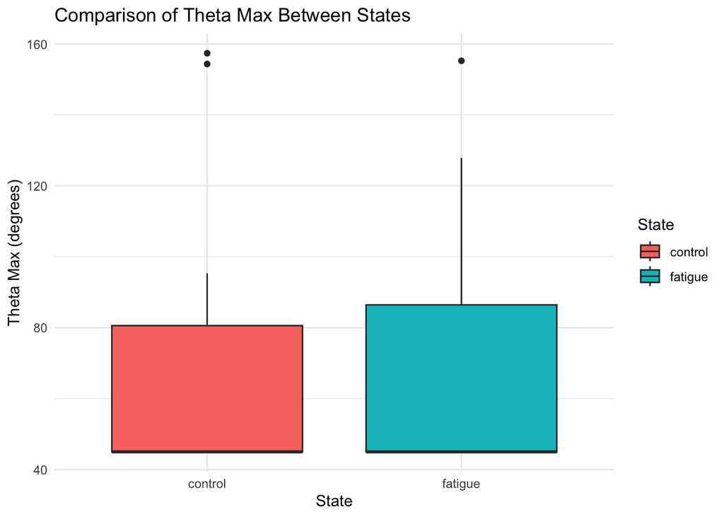

```r
ggplot(best_models_filtered, aes(x = State, y = theta_max, fill = State)) +
  geom_boxplot() +
  theme_minimal() +
  labs(title = 'Comparison of Theta Max Between States',
       x = 'State',
       y = 'Theta Max (degrees)',
       fill = 'State')
```

## Author Contributions

- Jonah and Ana were responsible for developing the methodology, ensuring our approach was robust and scientifically sound.
- Katie led the data collection and experimental setup, meticulously organizing and executing the tasks necessary for acquiring our data set, as well as some minor formatting edits for visual appeal.
- Jess contributed to the interpretation of our results and writing the discussion, providing valuable insights that helped shape our discussion and conclusions, along with the creation of the bibliography.
- Jonah focused on data analysis and the drafting of the project report. This included writing the code for data manipulation, performing statistical analyses, and generating the visual representations of our findings.

## References

Chen, Trevor C, Kazunori Nosaka, and Paul Sacco. 2007. “Intensity of Eccentric Exercise, Shift of Optimum Angle, and the Magnitude of Repeated-Bout Effect.” *Journal of Applied Physiology* 102 (3): 992–99.

Enoka, Roger M, and Jacques Duchateau. 2008. “Muscle Fatigue: What, Why and How It Influences Muscle Function.” *The Journal of Physiology* 586 (1): 11–23.

Jones, David A. 2010. “Changes in the Force–Velocity Relationship of Fatigued Muscle: Implications for Power Production and Possible Causes.” *The Journal of Physiology* 588 (16): 2977–86.